# TidyTemplate

2021-04-02

# TidyTuesday

Join the R4DS Online Learning Community in the weekly #TidyTuesday event! Every week we post a raw dataset, a chart or article related to that dataset, and ask you to explore the data. While the dataset will be “tamed”, it will not always be tidy! As such you might need to apply various R for Data Science techniques to wrangle the data into a true tidy format. The goal of TidyTuesday is to apply your R skills, get feedback, explore other’s work, and connect with the greater #RStats community! As such we encourage everyone of all skills to participate!

# Load the weekly Data

Dowload the weekly data and make available in the `tt` object.

```r
tt <- tt_load("2021-03-09")
```

```
## --- Compiling #TidyTuesday Information for 2021-03-09 ----
```

```
## --- There are 2 files available ---
```

```
## Only 10 Github queries remaining until 2021-04-02 10:32:19 AM PDT.
```

```
## --- Starting Download ---
```

[output not shown]

[output not shown]

[output not shown]

```
## --- Download complete ---
```

```r
movies = tt$movies
```

# Readme

```r
tt
```

[output not shown]

# Glimpse Data

Take an initial look at the format of the data available.

```r
tt %>%
  map(glimpse)
```

```
## Rows: 8,839
## Columns: 5
## $ year    <dbl> 1888, 1892, 1895, 1895, 1896, 1896, 1896, 1896, 1897, 1898,...
## $ id      <dbl> 8040, 5433, 6200, 5444, 5406, 5445, 6199, 4982, 9328, 4978,...
## $ imdb_id <chr> "0392728", "0000003", "0132134", "0000014", "0000131", "022...
## $ title   <chr> "Roundhay Garden Scene", "Pauvre Pierrot", "The Execution o...
## $ rating  <dbl> 0, 0, 0, 0, 0, 0, 0, 0, 0, 0, 0, 0, 3, 0, 0, 0, 0, 0, 0, 0,...
## Rows: 1,794
## Columns: 34
## $ year          <dbl> 2013, 2012, 2013, 2013, 2013, 2013, 2013, 2013, 2013,...
## $ imdb          <chr> "tt1711425", "tt1343727", "tt2024544", "tt1272878", "...
## $ title         <chr> "21 &amp; Over", "Dredd 3D", "12 Years a Slave", "2 G...
## $ test          <chr> "notalk", "ok-disagree", "notalk-disagree", "notalk",...
## $ clean_test    <chr> "notalk", "ok", "notalk", "notalk", "men", "men", "no...
## $ binary        <chr> "FAIL", "PASS", "FAIL", "FAIL", "FAIL", "FAIL", "FAIL...
```

[output cut: 28 more lines]

```
## $raw_bechdel
## # A tibble: 8,839 x 5
##     year    id imdb_id title                                 rating
##    <dbl> <dbl> <chr>   <chr>                                  <dbl>
##  1  1888  8040 0392728 Roundhay Garden Scene                      0
##  2  1892  5433 0000003 Pauvre Pierrot                             0
##  3  1895  6200 0132134 The Execution of Mary, Queen of Scots      0
##  4  1895  5444 0000014 Tables Turned on the Gardener              0
##  5  1896  5406 0000131 Une nuit terrible                          0
##  6  1896  5445 0223341 La fee aux choux                           0
##  7  1896  6199 0000012 The Arrival of a Train                     0
##  8  1896  4982 0000091 The House of the Devil                     0
##  9  1897  9328 0000041 Bataille de neige                          0
## 10  1898  4978 0135696 Four Heads Are Better Than One             0
## # ... with 8,829 more rows
##
## $movies
## # A tibble: 1,794 x 34
##     year imdb  title test  clean_test binary budget domgross intgross code
##    <dbl> <chr> <chr> <chr> <chr>      <chr>   <dbl> <chr>    <chr>    <chr>
##  1  2013 tt17~ 21 &~ nota~ notalk     FAIL   1.30e7 25682380 42195766 2013~
##  2  2012 tt13~ Dred~ ok-d~ ok         PASS   4.50e7 13414714 40868994 2012~
##  3  2013 tt20~ 12 Y~ nota~ notalk     FAIL   2.00e7 53107035 1586070~ 2013~
##  4  2013 tt12~ 2 Gu~ nota~ notalk     FAIL   6.10e7 75612460 1324930~ 2013~
##  5  2013 tt04~ 42    men   men        FAIL   4.00e7 95020213 95020213 2013~
##  6  2013 tt13~ 47 R~ men   men        FAIL   2.25e8 38362475 1458038~ 2013~
##  7  2013 tt16~ A Go~ nota~ notalk     FAIL   9.20e7 67349198 3042491~ 2013~
##  8  2013 tt21~ Abou~ ok-d~ ok         PASS   1.20e7 15323921 87324746 2013~
##  9  2013 tt18~ Admi~ ok    ok         PASS   1.30e7 18007317 18007317 2013~
## 10  2013 tt18~ Afte~ nota~ notalk     FAIL   1.30e8 60522097 2443731~ 2013~
## # ... with 1,784 more rows, and 24 more variables: budget_2013 <dbl>,
## #   domgross_2013 <chr>, intgross_2013 <chr>, period_code <dbl>,
## #   decade_code <dbl>, imdb_id <chr>, plot <chr>, rated <chr>, response <lgl>,
## #   language <chr>, country <chr>, writer <chr>, metascore <dbl>,
## #   imdb_rating <dbl>, director <chr>, released <chr>, actors <chr>,
## #   genre <chr>, awards <chr>, runtime <chr>, type <chr>, poster <chr>,
## #   imdb_votes <dbl>, error <lgl>
```

# Wrangle

Explore the data and process it into a nice format for plotting! Access each dataset by name by using a dollarsign after the `tt` object and then the name of the data set.

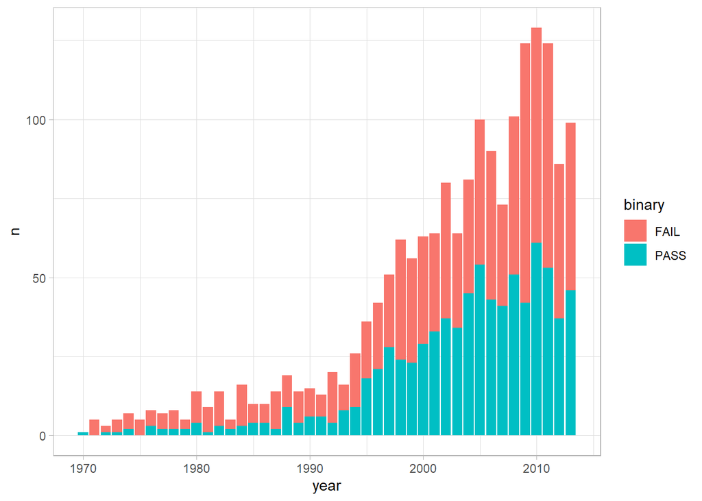

```r
p <- movies %>%
  count(year, binary) %>%
  ggplot(aes(year, n, fill=binary)) +
  geom_col()
print(p)
```